Video lecture · 15 minutes

# Claude Skills

Stop building agents. Start packaging expertise — by hand, or by letting Claude write the skill for you.

Prof. Engr. Faiz ul Haque Zeya

Bahria University Karachi · Founder & CEO, Transys

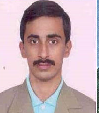

[0:00 – 0:50] Assalam-o-Alaikum and welcome. I am Faiz ul Haque Zeya. I teach software engineering at Bahria University Karachi and I run an AI company, Transys. Today’s topic is one of the most practical ideas to come out of Anthropic in the last year: Claude Skills. Recently, Anthropic’s engineers made a surprising argument. They said: stop building a new AI agent for every task. Build skills instead. In the next fifteen minutes, I will explain what a skill actually is, how Claude loads it without wasting memory, and then the two ways to create one. First, the manual way, where you write the skill file yourself. Second, the automatic way, where you simply describe your workflow and Claude writes, tests and packages the skill for you. I will show three automatic examples from my own work as a teacher. So stay till the end.

The shift

## From a zoo of agents to one agent with a library

### The old way

- A finance agent, a docs agent, a review agent…
- Each with its own prompts, tools and code
- Smart, but no real domain expertise
- Hard to share, test or maintain

### The skills way

- One general agent: Claude
- A library of skills it loads on demand
- Each skill = packaged procedural know-how
- Shareable folders, versioned like code

Idea from “Don’t Build Agents, Build Skills Instead” — Barry Zhang & Mahesh Murag, Anthropic · 2

[0:50 – 2:10] Let’s start with the problem. In 2025 everybody was building agents. A finance agent, a research agent, a coding agent, a document agent. Each one had its own prompts, its own tools, its own scaffolding. Anthropic’s engineers noticed something. Their single general agent, Claude, working with a file system and the ability to run code, was already capable enough for almost any domain. What it lacked was not intelligence. It lacked expertise. Think of it this way: would you rather hand your tax return to a genius mathematician who has never seen a tax form, or to an experienced accountant? Claude is the genius. A skill is how you turn that genius into the experienced accountant, for your exact process. So instead of building ten agents, you build one agent and give it a library of skills. Each skill packages the procedural knowledge for one kind of task. And because skills are just folders of files, you can share them, version them, and improve them, exactly like software.

Definition

## A skill is just a folder

A folder with one required file, **SKILL.md**, plus any scripts, templates and reference docs Claude needs to do one kind of job the same way every time.

Works in the Claude app, Claude Code and the Claude API.

lecture-deck/

├── SKILL.md # required

├── references/

│ └── style-guide.md

├── scripts/

│ └── build_deck.py

└── assets/

└── bahria-logo.png

3

[2:10 – 3:20] So what exactly is a skill? Anthropic defines it as an organized collection of files that packages procedural knowledge for an agent. In plain words: a skill is a folder. That’s it. Inside the folder there is exactly one file that must exist, called SKILL.md, in capital letters. That file holds the instructions. Next to it you can put anything Claude might need: reference documents, like a style guide; scripts, like a Python program that builds a slide deck; and assets, like your university logo or a template. Look at the example on screen: a skill called lecture-deck. Notice there is no special programming framework here, no SDK, no server. It is Markdown and files. That’s why people in accounting, legal and HR, not just programmers, are writing skills today. And the same skill folder works across the Claude app, Claude Code in the terminal, and the Claude API.

Anatomy

## Inside SKILL.md: frontmatter + body

---

name: lecture-deck

description: Builds BUKC lecture slides from a topic outline. Use when the user asks for lecture slides or a class deck.

---

# Lecture Deck

1. Ask for course code and topic.

2. Follow references/style-guide.md

3. Run scripts/build_deck.py

### name

Lowercase with hyphens, up to 64 characters.

### description

What it does and **when to use it**. Claude reads this to decide. The most important line you write.

### body

Plain steps, rules and pointers to other files.

4

[3:20 – 4:40] Let’s open SKILL.md. It has two parts. At the top, between three dashes, is the YAML frontmatter. Only two fields matter here. First, the name: lowercase letters and hyphens, up to sixty-four characters. Second, and this is the most important line in the whole skill, the description. The description says what the skill does and, critically, when to use it. Why does that matter so much? Because Claude never reads your full instructions until it decides the skill is relevant, and it makes that decision by reading only the description. A vague description, like “helps with slides”, and your skill will never fire. A precise one, like “Builds BUKC lecture slides from a topic outline; use when the user asks for lecture slides or a class deck”, and it fires exactly when you want. Below the frontmatter is the body: normal Markdown, step-by-step instructions, rules, and pointers to other files in the folder, like the style guide and the build script.

The key trick

## Progressive disclosure: load only what’s needed

1

### Metadata

Name + description of every skill. Always in context, roughly 100 tokens each.

Loaded: at startup

2

### SKILL.md body

The full instructions. Keep it lean, under about 5,000 tokens.

Loaded: when the task matches

3

### Files & scripts

References read on demand; scripts are run, so their code never fills the context.

Loaded: only if needed

5

[4:40 – 6:00] Now the clever part, the reason skills scale. Anthropic calls it progressive disclosure. Claude’s context window is like its working memory, and it is limited. If you installed a hundred skills and Claude read all of them at once, that memory would be full before you even asked a question. So skills load in three levels. Level one: metadata. At startup Claude reads only the name and description of each skill, roughly a hundred tokens each. So a hundred skills cost very little. Level two: the body of SKILL.md. Only when your request matches a description does Claude open that file and read the instructions. Level three: the extra files. The style guide is read only if the instructions point to it and the task needs it. And scripts are executed, not read, so a thousand-line Python program costs almost nothing in memory; Claude only sees its output. This is why a skill can carry a huge amount of expertise without slowing Claude down.

Where skills fit

## Prompts, MCP and skills each have a job

| Piece | What it gives Claude | Analogy |
| --- | --- | --- |
| **Prompt** | One-time instructions for this chat | Telling a colleague once |
| **MCP server** | Connectivity: access to tools and data | Giving them the keys |
| **Skill** | Reusable expertise: how to do the job | Handing over the SOP binder |
| **Agent** | The model plus its runtime loop | The employee |

MCP connects Claude to the world. Skills teach it what to do once connected.

6

[6:00 – 6:50] A quick comparison, because students often confuse these. A prompt is one-time instruction for one conversation; it’s gone next time. An MCP server, the Model Context Protocol, gives Claude connectivity: access to Gmail, a database, GitHub. That’s giving your employee the keys to the building. A skill gives Claude expertise: the standard operating procedure for how your organization does a particular job. And the agent is the employee itself, the model running in its loop. Anthropic’s framing is simple: MCP connects Claude to the world, skills teach Claude what to do once it’s connected. They are complementary, not competing. In fact, many good skills say: use this MCP tool, in this order, with these checks.

Method 1 · Manual creation

## Write the skill yourself in four steps

### 1. Make the folder

~/.claude/skills/lecture-deck/

Personal skills. Use .claude/skills/ inside a repo for a team.

### 2. Write SKILL.md

Name, a sharp description with trigger phrases, then numbered steps.

### 3. Add resources

Templates, examples and scripts the steps point to.

### 4. Install and test

Claude app: zip the folder and upload it in Settings. Then ask a real request and refine.

Claude Code: personal ~/.claude/skills/ · project .claude/skills/ · API: /v1/skills endpoints · 7

[6:50 – 8:40] Method one: manual creation. You are the author. Step one, make the folder. In Claude Code, personal skills live in your home directory under dot-claude slash skills; a folder there is available in every project. If you want the whole team to share a skill, put it inside the repository under dot-claude slash skills and commit it to Git. Step two, write SKILL.md. Give it a name, spend real thought on the description, include the phrases your users actually say, like “make lecture slides” or “class deck”, and then write the body as numbered steps, the way you would write a lab manual for a new teaching assistant. Step three, add resources: a template, one or two good examples of finished output, maybe a script for the mechanical part. Step four, install and test. In Claude Code, the skill is picked up from the folder. In the Claude app, you zip the folder and upload it in Settings. Developers can also upload skills through the API. Then test it: ask a real request, watch whether the skill fires, and check the output. If it doesn’t fire, the fix is almost always in the description. Manual creation gives you full control, and it’s the right choice when the procedure is sensitive or must follow a precise standard.

Method 2 · Automatic creation

## Describe the job. Claude writes the skill.

💬

### 1. Describe

“Create a skill that…” or, after a task, “turn what we just did into a skill.”

🔍

### 2. Interview

Claude asks about inputs, outputs, rules and edge cases.

</>

### 3. Draft & test

Writes SKILL.md and scripts, runs test prompts, tunes the description.

✔

### 4. You review

Read it, correct it, save it. Then it fires on its own.

Powered by Anthropic’s built-in **skill-creator** skill: a skill that builds skills.

8

[8:40 – 9:40] Method two: automatic creation. Here you don’t write the file at all. Anthropic ships a skill called skill-creator. Yes, a skill whose job is to build other skills. You just describe what you want. There are two common ways to start. One: say “create a skill that does X” and describe your process. Two, and this is my favourite: do the task once with Claude in a normal conversation, correct it until the result is right, and then say “turn what we just did into a skill.” Claude has the whole worked example in front of it. Then it interviews you: what are the inputs, what should the output look like, what rules must never be broken. It drafts SKILL.md, writes any helper scripts, runs a few test prompts, and adjusts the description so it triggers reliably. Your job is to review. Read it, fix anything wrong, and save. From then on it triggers automatically whenever a matching request comes in. Let me show you three examples from my own teaching work.

Automatic example 1

## Quiz builder from lecture notes

### What I typed

“Create a skill: from my lecture notes, make 10 MCQs across Bloom’s levels, four options each, one answer, with an answer key and explanations, exported for Moodle.”

### What Claude produced

mcq-quiz-builder/

├── SKILL.md

├── references/blooms-levels.md

└── scripts/to_moodle_xml.py

description: Generates graded MCQ quizzes from lecture notes or slides. Use when asked for a quiz, MCQs or practice questions.

9

[9:40 – 10:50] Example one: a quiz builder. Every week I need quizzes from my lecture notes. So I typed this request, which you see on the left. Create a skill: from my lecture notes, make ten multiple-choice questions spread across Bloom’s levels, four options each, one correct answer, with an answer key and explanations, exported so I can import into Moodle. Claude asked me a few questions. How many questions at each Bloom’s level? Should distractors be based on common student mistakes? Then it produced the folder on the right. A SKILL.md with the steps. A reference file explaining each Bloom’s level with sample verbs, which is only read when needed. And a small Python script that converts the questions into Moodle XML, because formatting is exactly the kind of mechanical job a script does better than a language model. Look at the description it wrote: it lists the trigger phrases, quiz, MCQs, practice questions. Now, any time I upload notes and say “make a quiz for SEN-429 week five”, this skill fires automatically. I didn’t write one line of it.

Automatic example 2

## Rubric grader, captured from a real session

### What I typed

(after grading 5 reports together) “Turn what we just did into a skill, so the next 40 are marked the same way.”

### What Claude captured

1. Read the rubric file I attach
2. Score each criterion with a quoted line of evidence
3. Flag anything borderline for me, never guess
4. Run scripts/marks_to_csv.py for the gradebook
5. Write two lines of feedback per student

10

[10:50 – 12:00] Example two shows the second route: capturing a skill from a real session. I had forty lab reports to mark against a rubric. I sat with Claude and graded the first five together. I corrected it several times: “quote the evidence”, “don’t award marks for length”, “if you’re unsure, flag it for me”. Once the fifth report came out exactly as I would have marked it, I typed: turn what we just did into a skill, so the next forty are marked the same way. Claude turned all my corrections into rules in the SKILL.md. Read the rubric I attach. Score each criterion with a quoted line of evidence. Flag borderline cases for a human; never guess. Run a script that writes marks into a CSV for the gradebook. And write two lines of feedback per student. Notice the important point: the expertise came from me, from my corrections. Claude simply packaged it. And I still review the flagged cases myself. The skill makes me consistent, it does not replace my judgment.

Automatic example 3

## Code-review feedback for student projects

### What I typed

“Create a skill that reviews a student’s Python repo against my SE checklist: tests, naming, docstrings, Git history. Be kind, be specific, don’t rewrite their code.”

### What the skill does

**Runs** pytest and a linter through scripts, so results are facts, not opinions

**Checks** each checklist item with file and line references

**Writes** three strengths, three fixes, one stretch goal

11

[12:00 – 13:00] Example three: code-review feedback for my software engineering students. I typed: create a skill that reviews a student’s Python repository against my software engineering checklist: tests, naming, docstrings, Git commit history. Be kind, be specific, and don’t rewrite their code for them. Claude built a skill that does three things. First, it runs pytest and a linter through scripts. This is important: Anthropic’s own engineers favour external, deterministic checks over the model just giving its opinion. A failing test is a fact. Second, it walks through each item on my checklist and cites the exact file and line. Third, it writes feedback in a fixed shape: three strengths, three fixes, and one stretch goal. The students get consistent, constructive feedback within minutes, and because the instructions say “don’t rewrite their code”, they still have to do the learning themselves.

Best practices

## Six rules for skills that actually work

### Sharp description

Say what and when, with real trigger words.

### One job per skill

Small skills compose better than one giant one.

### Lean SKILL.md

Move detail into reference files.

### Scripts for mechanics

Formatting, maths and checks belong in code.

### Test like software

Real prompts, version history, fix the smallest thing.

### Trust, then verify

Install skills only from sources you trust; read the scripts.

12

[13:00 – 14:10] Before we finish, six practical rules, whether you write skills by hand or let Claude write them. One: a sharp description. Say what the skill does and when to use it, with the actual words your users type. Two: one job per skill. Claude can combine several small skills in one task, so a quiz skill and a deck skill work better than one “teaching assistant” mega-skill. Three: keep SKILL.md lean, and push detail into reference files so progressive disclosure can do its work. Four: anything mechanical, formatting, calculations, validation, put in a script. Scripts are reliable and they don’t eat context. Five: treat skills like software. Test with real prompts, keep them in Git, and when something goes wrong, make the smallest fix that solves it. Six: security. A skill can contain code that Claude will run, so only install skills from sources you trust, and read the scripts before you use a skill someone else wrote.

Key takeaways

## Don’t build another agent. Teach the one you have.

- A skill is a folder with SKILL.md
- Progressive disclosure keeps it cheap
- Manual: full control for precise standards
- Automatic: describe it, review it, reuse it

Your homework: turn one task you repeat every week into a skill.

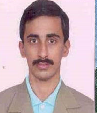

Faiz ul Haque Zeya

Like · Subscribe · Comment

[14:10 – 15:00] Let’s wrap up. Anthropic’s message is simple: don’t build another agent; teach the one you already have. A skill is just a folder with a SKILL.md file. Progressive disclosure means you can install many skills without filling Claude’s memory. You can create skills manually when you need full control and a precise standard, or automatically, by describing the job or saying “turn this into a skill”, and then reviewing what Claude wrote. And the skills I showed you today, the quiz builder, the rubric grader and the code reviewer, took minutes to create but will save me hours every semester. So here is your homework: pick one task you repeat every single week, and turn it into a skill. Then tell me in the comments what you built. If this lecture helped, please like, subscribe, and share it with a colleague. I am Faiz ul Haque Zeya. Thank you, and Allah Hafiz.